# Case Study 1

Domicia Herring & Taylor Bonar

2/20/2021

## Introduction

### a. The introduction needs to be written as if you are presenting the work to the CEO and CFO of Budweiser (your client) and that they only have had one class in statistics. If it sounds like a student presentation, that is not acceptable. You may assume that the CEO and CFO gave you the data and gave you the directive to report any interesting finding that you may uncover through your analysis.

### b. Briefly explain the purpose of the code. The explanations should appear as a sentence or two before or after the code chunk. Even though you will not be hiding the code chunks (so that I can see the code), you need to assume that the client can’t see them.

## Libraries & Package Setup

```r
# Uncomment installs if you have not downloaded packages before
#install.packages("dplyr")
# Load APIs
library(ggplot2)
library(dplyr)
library(maps)
library(mapproj)
library(stringr)
```

## Global Variable Setup

```r
# Importing input data
breweries <- read.csv(file.choose(), header = TRUE)
beers <- read.csv(file.choose(), header = TRUE)

#See dataframes
breweries
```

```
##     Brew_ID                                Name                City State
## 1         1                  NorthGate Brewing          Minneapolis    MN
## 2         2           Against the Grain Brewery          Louisville    KY
## 3         3            Jack's Abby Craft Lagers          Framingham    MA
## 4         4           Mike Hess Brewing Company           San Diego    CA
## 5         5             Fort Point Beer Company       San Francisco    CA
## 6         6               COAST Brewing Company          Charleston    SC
## 7         7        Great Divide Brewing Company              Denver    CO
## 8         8                    Tapistry Brewing            Bridgman    MI
## 9         9                    Big Lake Brewing             Holland    MI
## 10       10          The Mitten Brewing Company        Grand Rapids    MI
## 11       11                      Brewery Vivant        Grand Rapids    MI
## 12       12                    Petoskey Brewing            Petoskey    MI
## 13       13                  Blackrocks Brewery           Marquette    MI
## 14       14              Perrin Brewing Company       Comstock Park    MI
```

[output cut: 544 more lines]

```r
beers
```

```
##                                                      Name Beer_ID   ABV IBU
## 1                                                Pub Beer    1436 0.050  NA
## 2                                             Devil's Cup    2265 0.066  NA
## 3                                     Rise of the Phoenix    2264 0.071  NA
## 4                                                Sinister    2263 0.090  NA
## 5                                           Sex and Candy    2262 0.075  NA
## 6                                            Black Exodus    2261 0.077  NA
## 7                                     Lake Street Express    2260 0.045  NA
## 8                                                 Foreman    2259 0.065  NA
## 9                                                    Jade    2258 0.055  NA
## 10                                           Cone Crusher    2131 0.086  NA
## 11                                      Sophomoric Saison    2099 0.072  NA
## 12                                  Regional Ring Of Fire    2098 0.073  NA
## 13                                            Garce SelÃ©    2097 0.069  NA
## 14                                        Troll Destroyer    1980 0.085  NA
```

[output cut: 4807 more lines]

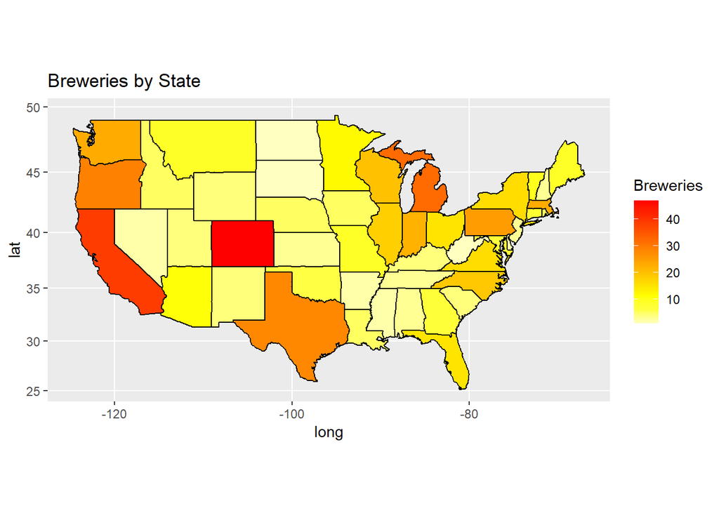

```r
# Cleaning Data
breweries$State <- str_replace_all(breweries$State, "(\\s+)", "")

## Analysis

### 1.   How many breweries are present in each state?

# Data tidying
## Remove DC as its not a state but capitol
breweriesStates <- filter(breweries,!grepl('DC', State))

# Data Transformation
## Create data frame with State name and abbreviation
stateLookup = data.frame(abb = state.abb, stateName = state.name)

## Merge stateLookup with breweriesMapData
breweriesStates2 = merge(breweriesStates,stateLookup,by.x="State",by.y="abb")

## count each occurrence of breweries in each state
breweriesMapData = count(breweriesStates2,stateName)
## remap columns for future merge of states and map
colnames(breweriesMapData) = c("region","Breweries")
breweriesMapData$region <- tolower(breweriesMapData$region)
## Create merge between states lat/long and breweries map data
states <- map_data("state")
map.df <- merge(states, breweriesMapData, by="region", all.x=T)
map.df <- map.df[order(map.df$order),]
ggplot(map.df, aes(x=long,y=lat,group=group))+
  geom_polygon(aes(fill=Breweries))+
  geom_path()+
  scale_fill_gradientn(colours=rev(heat.colors(10)),na.value="grey90")+ggtitle("Breweries by State")+coord_map()
```

### 2. Merge beer data with the breweries data. Print the first 6 observations and the last six observations to check the merged file. (RMD only, this does not need to be included in the presentation or the deck.)

```r
beerAndBreweries = merge(beers, breweries, by.x="Brewery_id", by.y="Brew_ID")
# Remap columns named "Name" to be more descriptive/ubiquitous
colnames(beerAndBreweries)[2] = "Beer_Name"
colnames(beerAndBreweries)[8] = "Brewery_Name"
head(beerAndBreweries)
```

```
##   Brewery_id     Beer_Name Beer_ID   ABV IBU
## 1          1  Get Together    2692 0.045  50
## 2          1 Maggie's Leap    2691 0.049  26
## 3          1    Wall's End    2690 0.048  19
## 4          1       Pumpion    2689 0.060  38
## 5          1    Stronghold    2688 0.060  25
## 6          1   Parapet ESB    2687 0.056  47
##                                 Style Ounces       Brewery_Name        City
## 1                        American IPA     16 NorthGate Brewing  Minneapolis
## 2                  Milk / Sweet Stout     16 NorthGate Brewing  Minneapolis
## 3                   English Brown Ale     16 NorthGate Brewing  Minneapolis
## 4                         Pumpkin Ale     16 NorthGate Brewing  Minneapolis
## 5                     American Porter     16 NorthGate Brewing  Minneapolis
## 6 Extra Special / Strong Bitter (ESB)     16 NorthGate Brewing  Minneapolis
##   State
## 1    MN
## 2    MN
## 3    MN
## 4    MN
## 5    MN
## 6    MN
```

```r
tail(beerAndBreweries)
```

```
##      Brewery_id                 Beer_Name Beer_ID   ABV IBU
## 2405        556             Pilsner Ukiah      98 0.055  NA
## 2406        557  Heinnieweisse Weissebier      52 0.049  NA
## 2407        557           Snapperhead IPA      51 0.068  NA
## 2408        557         Moo Thunder Stout      50 0.049  NA
## 2409        557         Porkslap Pale Ale      49 0.043  NA
## 2410        558 Urban Wilderness Pale Ale      30 0.049  NA
##                        Style Ounces                  Brewery_Name          City
## 2405         German Pilsener     12         Ukiah Brewing Company         Ukiah
## 2406              Hefeweizen     12       Butternuts Beer and Ale Garrattsville
## 2407            American IPA     12       Butternuts Beer and Ale Garrattsville
## 2408      Milk / Sweet Stout     12       Butternuts Beer and Ale Garrattsville
## 2409 American Pale Ale (APA)     12       Butternuts Beer and Ale Garrattsville
## 2410        English Pale Ale     12 Sleeping Lady Brewing Company     Anchorage
##      State
## 2405    CA
## 2406    NY
## 2407    NY
## 2408    NY
## 2409    NY
## 2410    AK
```

### 3. Address the missing values in each column.

#Remove rows with na values

```r
beerAndBreweries2 <- na.omit(beerAndBreweries)
beerAndBreweries2
```

```
##      Brewery_id                                           Beer_Name Beer_ID
## 1             1                                        Get Together    2692
## 2             1                                       Maggie's Leap    2691
## 3             1                                          Wall's End    2690
## 4             1                                             Pumpion    2689
## 5             1                                          Stronghold    2688
## 6             1                                         Parapet ESB    2687
## 7             2                                      Citra Ass Down    2686
## 8             2                                      London Balling    2685
## 9             2                                                35 K    2684
## 10            2                                              A Beer    2683
## 11            2                                     Rules are Rules    2682
## 12            2                                       Flesh Gourd'n    2681
## 13            2                                            Sho'nuff    2680
## 14            2                                         Bloody Show    2679
```

[output cut: 4203 more lines]

### 4. Compute the median alcohol content and international bitterness unit for each state. Plot a bar chart to compare.

#Arrange to see in desc order by ABV

```r
beerAndBreweries2 %>% group_by(State) %>% summarize(medianABV = median(ABV), count = n()) %>% arrange(desc(medianABV)) %>% print()
```

```
## # A tibble: 50 x 3
##    State medianABV count
##    <chr>     <dbl> <int>
##  1 ME        0.067     7
##  2 CO        0.065   146
##  3 OK        0.063    11
##  4 FL        0.062    37
##  5 GA        0.062     7
##  6 WV        0.062     2
##  7 CT        0.061     6
##  8 NC        0.061    30
##  9 NM        0.061     6
## 10 AL        0.06      9
## # ... with 40 more rows
```

```r
#Arrange to see in order by IBU
beerAndBreweries2 %>% group_by(State) %>% summarize(medianIBU = median(IBU), count = n()) %>% arrange(desc(medianIBU)) %>% print()
```

```
## # A tibble: 50 x 3
##    State medianIBU count
##    <chr>     <dbl> <int>
##  1 ME         61       7
##  2 WV         57.5     2
##  3 FL         55      37
##  4 GA         55       7
##  5 DE         52       1
##  6 NM         51       6
##  7 NH         48.5     2
##  8 DC         47.5     4
##  9 NY         47      46
## 10 AK         46      17
## # ... with 40 more rows
```

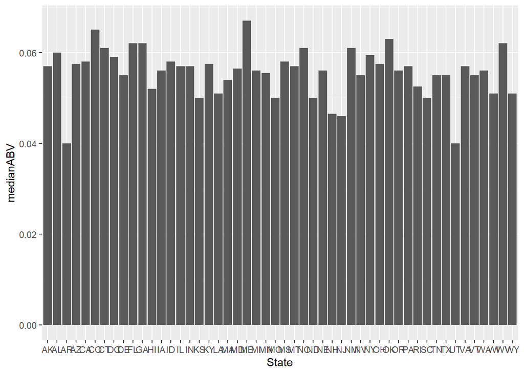

```r
#Bar Chart to visualize ABV by state
beerAndBreweries2 %>% group_by(State) %>% summarize(medianABV = median(ABV), count = n()) %>% ggplot(aes(x = State, y = medianABV)) + geom_col()
```

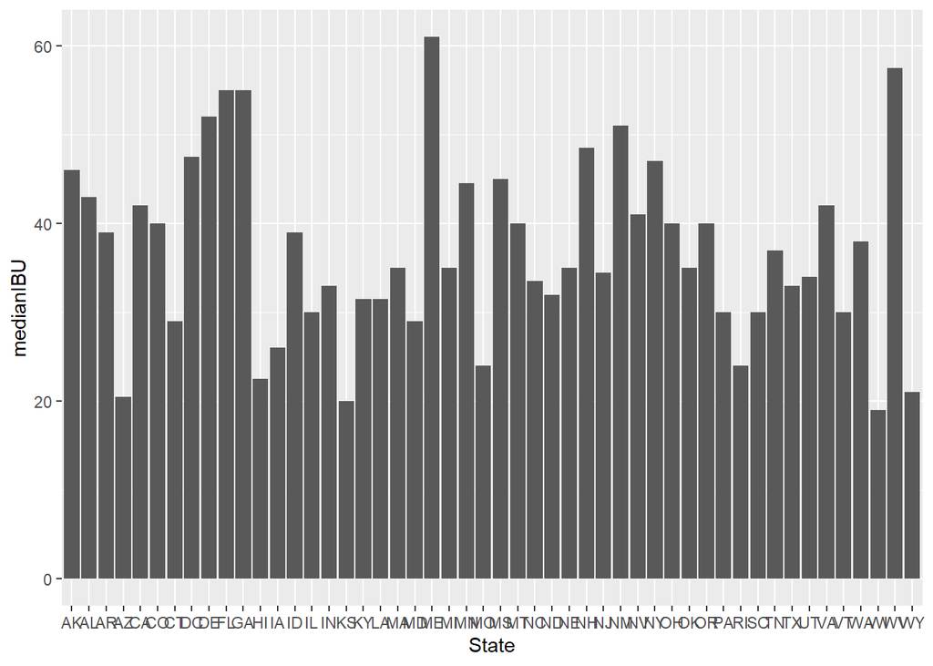

```r
#Bar Chart to visualize IBU by state
beerAndBreweries2 %>% group_by(State) %>% summarize(medianIBU = median(IBU), count = n()) %>% ggplot(aes(x = State, y = medianIBU)) + geom_col()
```

### 5. Which state has the maximum alcoholic (ABV) beer? Which state has the most bitter (IBU) beer?

```r
#Arrange to see in desc order by ABV
beerAndBreweries2 %>% group_by(State) %>% summarize(maxABV = max(ABV), count = n()) %>% arrange(desc(maxABV)) %>% print(n = 1)
```

```
## # A tibble: 50 x 3
##   State maxABV count
##   <chr>  <dbl> <int>
## 1 KY     0.125    14
## # ... with 49 more rows
```

```r
#Arrange to see in order by IBU
beerAndBreweries2 %>% group_by(State) %>% summarize(maxIBU = max(IBU), count = n()) %>% arrange(desc(maxIBU)) %>% print(n = 1)
```

```
## # A tibble: 50 x 3
##   State maxIBU count
##   <chr>  <int> <int>
## 1 OR       138    87
## # ... with 49 more rows
```

### 6. Comment on the summary statistics and distribution of the ABV variable.

```r
summary(beerAndBreweries2$ABV)
```

```
##    Min. 1st Qu.  Median    Mean 3rd Qu.    Max.
## 0.02700 0.05000 0.05700 0.05991 0.06800 0.12500
```

### 7. Is there an apparent relationship between the bitterness of the beer and its alcoholic content? Draw a scatter plot. Make your best judgment of a relationship and EXPLAIN your answer.

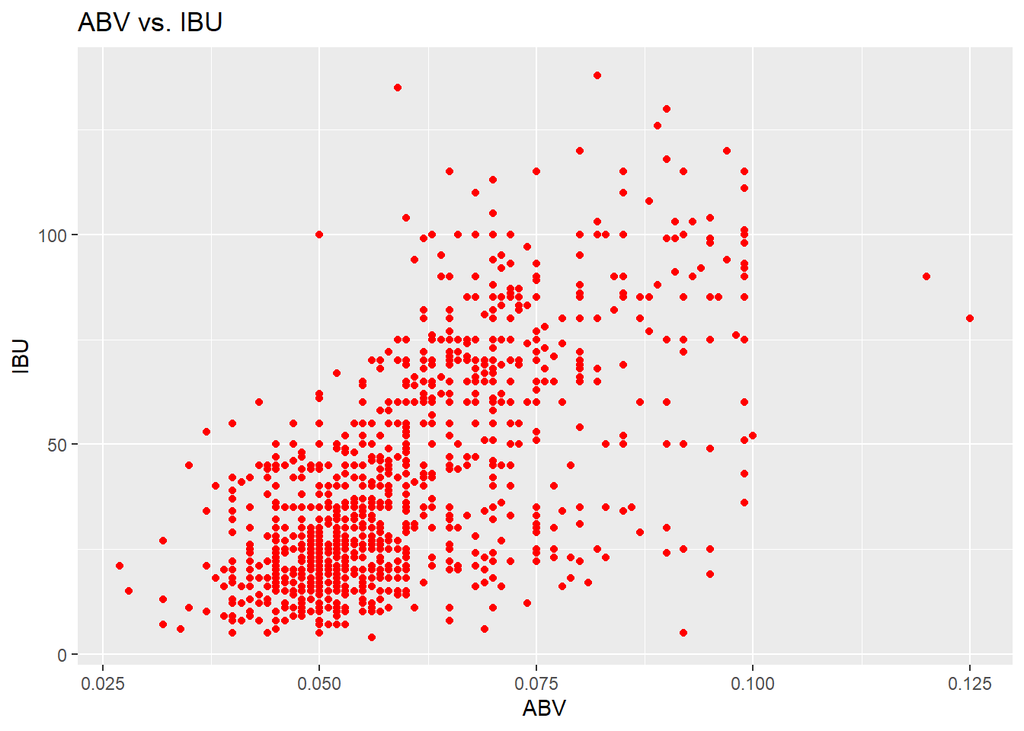

```r
beerAndBreweries2 %>% ggplot(aes(x=ABV, y=IBU)) + geom_point(colour = "red") + ggtitle("ABV vs. IBU") +
  xlab("ABV") + ylab("IBU")
```

### 8. Budweiser would also like to investigate the difference with respect to IBU and ABV between IPAs (India Pale Ales) and other types of Ale (any beer with “Ale” in its name other than IPA). You decide to use KNN classification to investigate this relationship. Provide statistical evidence one way or the other. You can of course assume your audience is comfortable with percentages … KNN is very easy to understand conceptually.

```r
#Filter for all styles that contain 'Ale' and create a new dataframe.
Ale <- beerAndBreweries2 %>% select(Style,ABV,IBU) %>%filter(stringr::str_detect(Style, 'Ale'))
#Filter for all styles that contain 'India Pale Ale' and create a new dataframe.
IndiaAle <- Ale %>%filter(stringr::str_detect(Style, 'India Pale Ale'))
```

### 9. Knock their socks off! Find one other useful inference from the data that you feel Budweiser may be able to find value in. You must convince them why it is important and back up your conviction with appropriate statistical evidence.